# corr_matrix

Jordan Lee

12/1/2020

# run step1_clean.ipynb first

# Correlation Matrix

https://uc-r.github.io/hc_clustering

https://stats.stackexchange.com/questions/2976/clustering-variables-based-on-correlations-between-them

```r
########## hardcoded
ftsets <- '../data/exact_match/best_models_BRCA.tsv'
upsetmode <- 'distinct'
init_vector <- c(clust1 = 0, clust2 = 0, clust3=0) # where len == n_clusters
team_order_upset <- c('JADBIO', 'CloudForest', 'AKLIMATE', 'SUBSCOPE', 'SciKitGrid')

file = '../data/heatmap/BRCA_vals_muta.tsv'
cancer = 'BRCA'
datatype <- 'B:MUTA:'

# n_clusters <- 2
##########
```

### Data Prep

Read in file containing Theo’s raw tarball values for features selected by teams (one best model per team). Reformat. Data format row:col:val is sample:feature:tarball_value

**TODO**

- rownames(df) line assumes the first col is the sample col

### Clustering features based on signal

Cluster features based on signal (from raw tarball).

1. Identify the strongest clustering structure of several methods `"average", "single", "complete", "ward"` for our data
2. Apply best clustering method in agglomerative clustering (AGNES) `agnes()`

Why AGNES instead of DIANA?

- Agglomerative clustering (AGNES). Won’t be using divisice hierarchial clustering (DIANA)
- Use `agnes()` instead of `hclust`

Agglomerative coefficient

- Measure of the clustering structure. “measure dissimilarity of object to the first cluster it joins, divided by the dissimilarity of the final merger in the cluster analysis, averaged across samples”. larger == larger strength of clustering
- AC tends to increase with sample size
- Can be compared to the silhouette coefficient

```
##      ward  complete   average    single
## 0.2808419 0.2376309 0.1909208 0.1624526
```

```
## [1] "method with largest agglomerative coefficient:"
```

```
## [1] "ward"
```

```r
library(factoextra)
```

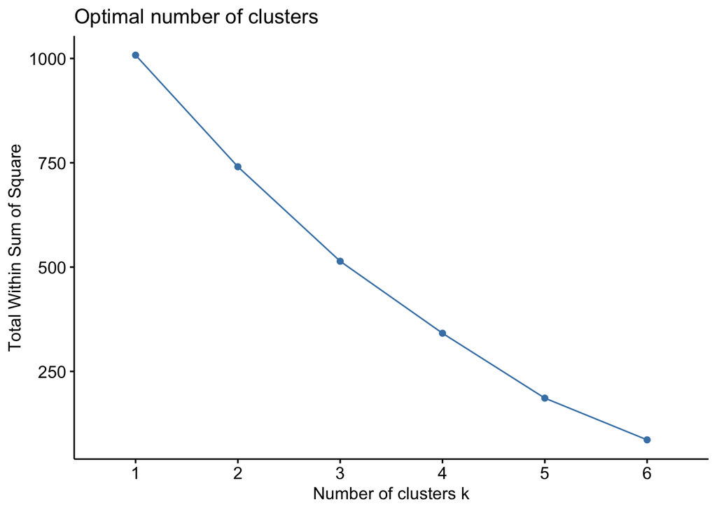

```r
library(NbClust)

######
# hcut
######
# Find optimal n clusters
# 1. WSS
res_wss <-fviz_nbclust(df, FUNcluster = hcut, method = "wss", k.max = 6, print.summary = TRUE) #switch to 6 to avoid error
# print(res_wss$labels)
res_wss
```

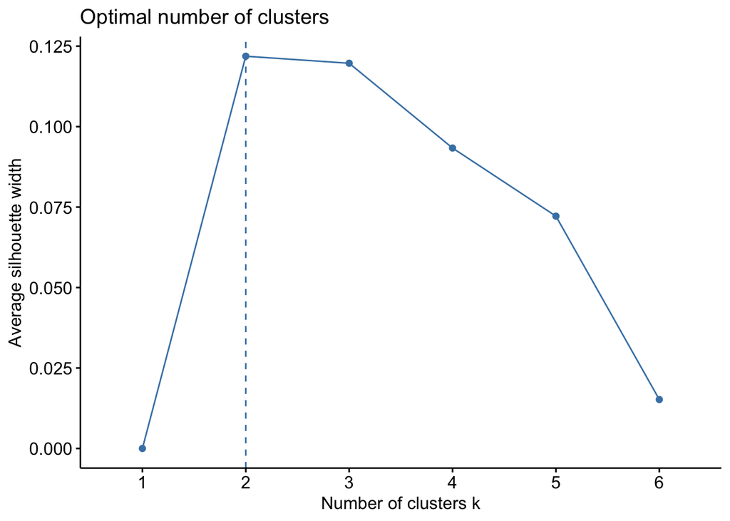

```r
# 2. Silhouette
res_sill <-fviz_nbclust(df, FUNcluster = hcut, method = "silhouette", k.max = 6, print.summary = TRUE) #switch to 6 to avoid error
res_sill
```

```r
# expand to print the opti number
data <- res_sill$data[order(res_sill$data$y, decreasing = TRUE),]
n_clusters <- data[1,1]
print('optimal number of clusters')
```

```
## [1] "optimal number of clusters"
```

```r
print(n_clusters)
```

```
## [1] 2
## Levels: 1 2 3 4 5 6
```

```r
# add one
n_clusters <- n_clusters %>% as.integer()+1

#######
#B. Kmeans**
#######
# 1. kmeans clustering
# fviz_nbclust(df, kmeans, method = "wss", print.summary = TRUE) #err
```

### Dendrogram

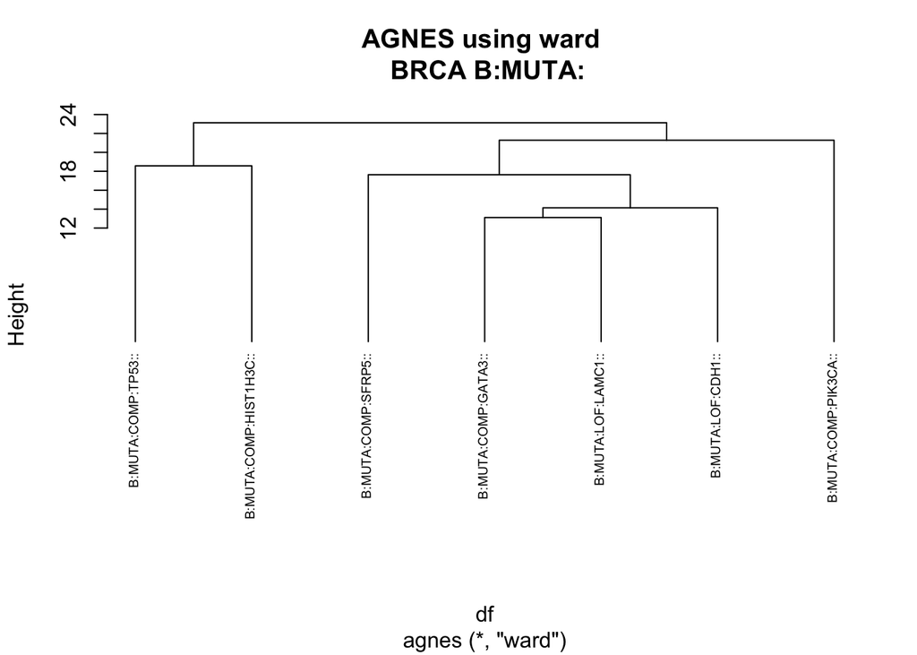

```r
# Plot
hc <- agnes(df, method = best_method)
pltree(hc, cex = 0.6, hang = -50, main = paste("AGNES using",best_method,'\n', cancer, datatype))
```

How many features in each cluster?

| clusterID | n_members |
| --- | --- |
| 1 | 2 |
| 2 | 4 |
| 3 | 1 |

Specifically which features? (head of data)

```
##   clusterID                    fts
## 2         1 B:MUTA:COMP:HIST1H3C::
## 3         2    B:MUTA:COMP:SFRP5::
## 5         2    B:MUTA:COMP:GATA3::
## 6         2      B:MUTA:LOF:CDH1::
## 7         2     B:MUTA:LOF:LAMC1::
## 4         3   B:MUTA:COMP:PIK3CA::
```

### Now examine in context of teams

Read in best model from each team. Which teams?

```
## [1] "gnosis_1_BRCA"
## [1] "found 0 ft"
## [1] "CF|All_Top 100_BRCA"
## [1] "found 0 ft"
## [1] "AKLIMATE_BRCA_reduced_model_1000_feature_set_BRCA"
## [1] "found 0 ft"
## [1] "nn_jg_2020-03-20_top1kfreq:BRCA_BRCA"
## [1] "found 0 ft"
## [1] "fbedeBIC_BRCA"
## [1] "found >= 1 ft"
```

Binary membership table

|  | gnosis_1_BRCA | CF\|All_Top 100_BRCA | AKLIMATE_BRCA_reduced_model_1000_feature_set_BRCA | nn_jg_2020-03-20_top1kfreq:BRCA_BRCA | fbedeBIC_BRCA |
| --- | --- | --- | --- | --- | --- |
| clust1 | 0 | 0 | 0 | 0 | 1 |
| clust2 | 0 | 0 | 0 | 0 | 1 |
| clust3 | 0 | 0 | 0 | 0 | 1 |

### Upset plot

Overlap of clusters

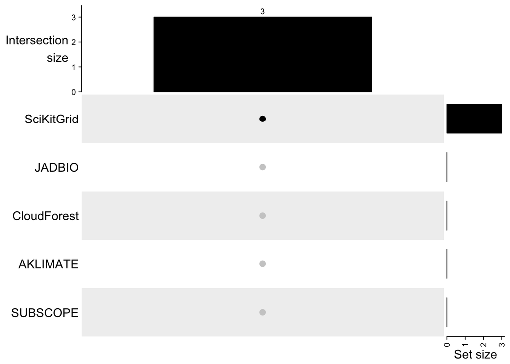

# Old code using correlations

**Click**

12/1/20

METHYLATION BRCA

skip this. eval=false for all code chunks

```r
# Correlation -
# Corelation matrix (coeff)
coeff <- cor(df, method = 'spearman')
Heatmap(
  coeff,
  name = paste(cancer, datatype, sep='\n'),
  cluster_rows = FALSE, cluster_columns = FALSE,
  show_column_dend = FALSE, show_row_dend = FALSE,
)
# Absolute corr
coeff <- abs(coeff)
Heatmap(
  coeff,
  name = paste(cancer, datatype, sep='\n'),
  cluster_rows = FALSE, cluster_columns = FALSE,
  show_column_dend = FALSE, show_row_dend = FALSE,
)
# cluster
d <- dist(coeff, method = 'euclidean', diag = TRUE)
# print(clust) # diagonal distance matrix
d_hclust <- hclust(d)
plot(d_hclust, xlab = "Feature", ylab = "")
print(d_hclust)
plot(d_hclust, xlab = "Feature", ylab = "")

# Create ft int to feature name table for interpreting cluster dendrogram
tab_clust <- cbind(seq(length(ordered_fts)), ordered_fts) %>% as.data.frame()
colnames(tab_clust) <- c('index', 'ft')
tab_clust
```

Now this is a manual step of picking clusters

```r
##### Hardcoded
clust1 <- c(2,4,26,23,29,30)
clust2 <- c(10,12,22,6,11)
clust3 <- c(17,8,9,28,16,24,19,1,5,7,14)
clust4 <- c(2,15,18,21,20,25,13,27)
nclust <- 4

ftsets <- '../../data/exact_match/best_models_BRCA.tsv'
upsetmode <- 'distinct'
#####

get_vec <- function(feature, results_vector, clust1, clust2, clust3, clust4){
  # for a ft, add which cluster apart of
  if (feature %in% clust1 == TRUE){
    # print('adding cluster 1 if not already present')
    results_vector['clust1'] <-1
  } else if (feature %in% clust2 == TRUE){
    # print('adding cluster 2 if not already present')
    results_vector['clust2'] <-1
  } else if (feature %in% clust3 == TRUE){
    # print('adding cluster 3 if not already present')
    results_vector['clust3'] <-1
  } else if (feature %in% clust4 == TRUE){
    # print('adding cluster 4 if not already present')
    results_vector['clust4'] <-1
  } else {
    print('-- error, ft not found in clusters:')
    print(feature)
    return(results_vector)
  }
  return(results_vector)
}
```

```r
# Convert clust int to feature name
clust1 <- tab_clust[clust1,][,'ft'] %>% as.vector()
clust2 <- tab_clust[clust2,][,'ft'] %>% as.vector()
clust3 <- tab_clust[clust3,][,'ft'] %>% as.vector()
clust4 <- tab_clust[clust4,][,'ft'] %>% as.vector()
```

```r
# Binary df. cols = [clusterID, Gnosis,CloudForest,AKLIMATE,SubSCOPE,SciKitGrid]
ftset_df <- fread(ftsets) %>% as.data.frame()
print(colnames(ftset_df))

# TODO dive into why fbed has unknown ft 'N:METH:cg26937500:CARD11:TssD142:Island'

loop <- 1
headers <- c()

# Iterate through teams (cols)
for (icol in seq(from = 2, to=ncol(ftset_df))){

  membership_clust <- c(clust1 = 0, clust2 = 0, clust3 = 0, clust4 = 0) # init

  # Pull team cols. skip col=1 which is featureID
  model <- colnames(ftset_df)[icol]
  headers <- c(headers, model)
  print(model)
  sub1 <- ftset_df[,c(1, icol)]
  sub1 <- sub1[!(apply(sub1, 1, function(y) any(y == 0))),] # rm rows with values 0
  model_fts <- sub1$featureID %>% as.vector() # pull all model filters

  # keep only feature type want. ex GEXP
  model_fts <- grep(datatype, model_fts, value=TRUE)

  if (length(model_fts) > 0 ){
    # Look up cluster
    # print('found >= 1 ft')
    for (mft in model_fts){
      membership_clust <- get_vec(
        mft, membership_clust,
        clust1, clust2, clust3, clust4
      )
    }
  } else {
    print('found 0 ft')
    model_fts <- 'NULL'
  }
  # print(membership_clust)

  # Create or append to results df
  if (loop == 1){
    tab_res <- membership_clust %>% as.data.frame()
    loop = 2
  } else {
    tab_res <- cbind(tab_res, membership_clust)
  }
}
colnames(tab_res) <- headers
kable(tab_res)
```

Plot upset plot

```r
m <- tab_res %>% as.matrix()
m <- make_comb_mat(m, mode = upsetmode)

# cs = comb_size(m)

ht = UpSet(
  m,
  pt_size = unit(3, "mm"),
  lwd = 3,
  top_annotation = upset_top_annotation(m, ylim = c(0, 1.1*max(cs))),
  # comb_col = c('black','orange','orange', "orange")[comb_degree(m)] # overlap =2 groups yellow
)

ht = draw(ht)
co = column_order(ht)

nc = ncol(m)
decorate_annotation("Intersection\nsize", {
    grid.text(cs[co],
        x = 1:nc,
        y = unit(cs[co], "native") + unit(1, "mm"),
        gp = gpar(fontsize = 8),
        just = "bottom",
        default.units = "native")
})
```